# EDAV Fall 2019 Final Project

Lin Jiang, Han Xu and Shuo Yang

11 December, 2019

# Introdution

Airbnb not only has changed the possibilites of travel and ways of living, but also brought new business potetials. We are interested in exploring the data generated from Airbnb, analyzing the data to find interesting facts about airbnb listing in New York. We hope we could generate some useful insights to provide guidances for customers and business suggestions for hosts.

# Get and Prepare Data

Data source: http://insideairbnb.com/get-the-data.html.

The data source provides a dataset of information from airbnb. We use the most recent (Sep, 2019) dataset for New York. The data is not cleaned, so we need to spend some time to tidy it.

Additionally, we define an active list as the onces received reviews within the past 12 months. Also we only includes data having price larger than zero, since we found that occurence of zero in price may due to error in data colleting.

For the cleaning fee (`cleaning_fee`) and security deposit (`security_deposit`), it is intuitive to replace the missings by 0. There are small amount of other variables are missing, we simply exclude the listings. It might be also due to collection error of the original data.

**amentities for backup**

```r
#split amenities into tidy data frame
##function to modify amenities string
split_amenities<-function(x){
  #x is an input string
  x<-str_replace_all(x,"[{}]",",") #remove {}
  temp<-str_split(x,"\\\"")[[1]] #split by \"
  temp[str_starts(temp,"[,]") | str_ends(temp,"[,]")]<-str_replace_all(temp[str_starts(temp,"[,]") | str_ends(temp,"[,]")],"[,]","|")
  temp<-str_remove(temp,"^\\|")
  temp<-str_remove(temp,"\\|$")
  temp<-temp[temp!=""]
  out<-paste(temp,collapse = "|")
  return(out)
}

#38 list has no amenities
dat2<-dat1%>%select(id, amenities)%>%
  rowwise()%>%
  mutate(amenity = split_amenities(amenities))
dat3<-dat2%>%separate_rows(amenity,sep="\\|")

##output amenities
#write_csv(dat3%>%select(-amenities),"./data/amenities_201909.csv")
```

# Analysis

## Price

Booking price is always an important thing both customers and hosts cares about. In this section, we want to explore the facts of airbnb booking price per night in the market of New York. For example, what kind of distribution does the varaible price has. Does different areas has different distributions? What is the correlation between price and other varaibles?

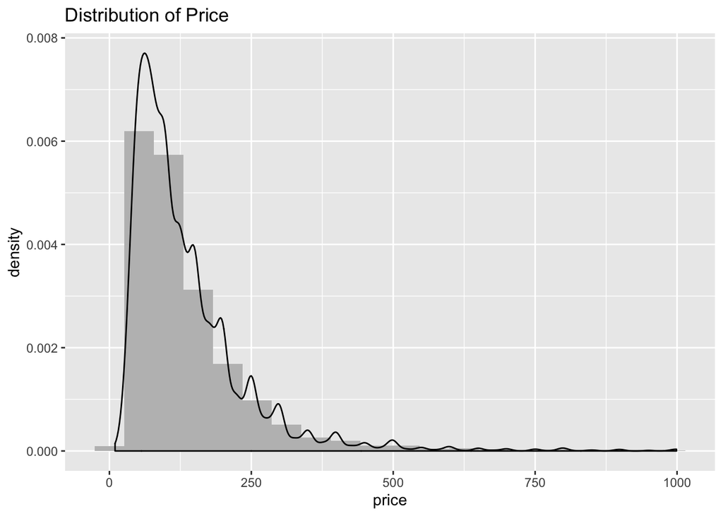

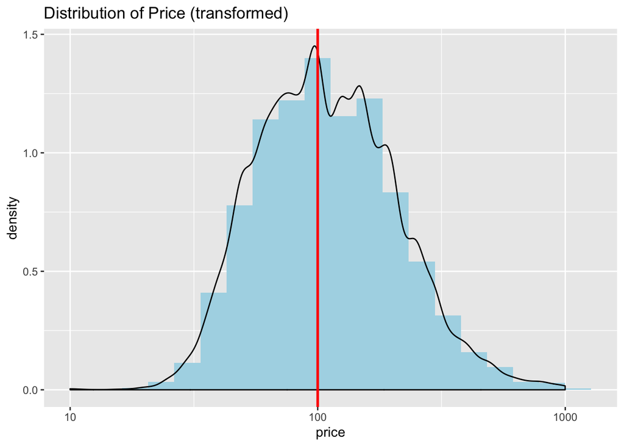

The first plot is a general plot of distribution of price, we could see that it is skewed right with very long tail. Thus, we do a log 10 transformation so that we could have better visualization. The distribution shows that the median of price is 100. The boxplot in the following also shows that most of the listings have a price under 200 dollars.

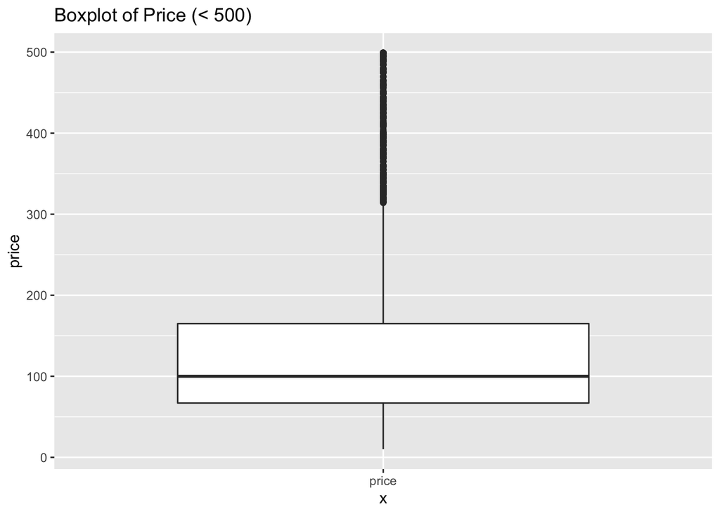

There are some listings have ridiculous high prices. What are these listings? Why are they so expensive? Let’s further explore these lisitngs with high prices.

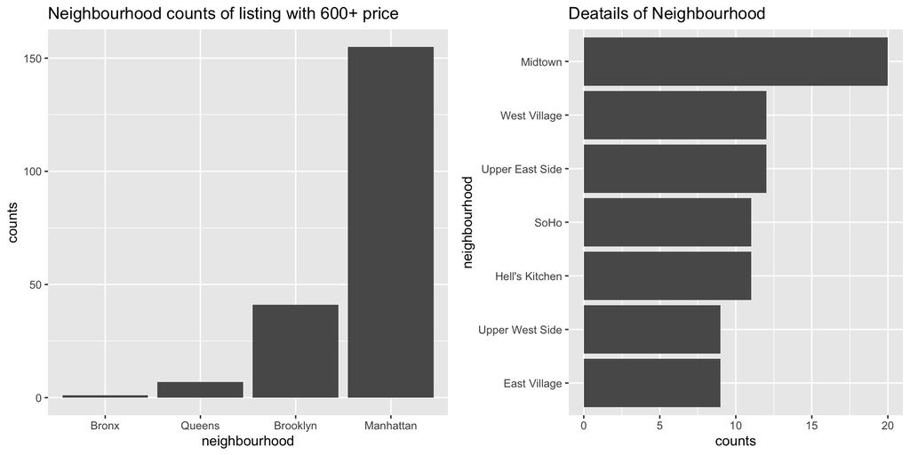

We foucus on the listings with price more than $600. We could see that most of the listings belongs to Manhattan area, which is reasonable. Futhermore, most of the listings with high price are in Midtown, which is also not unexpected, because Midtown is the central portion of Manhattan.

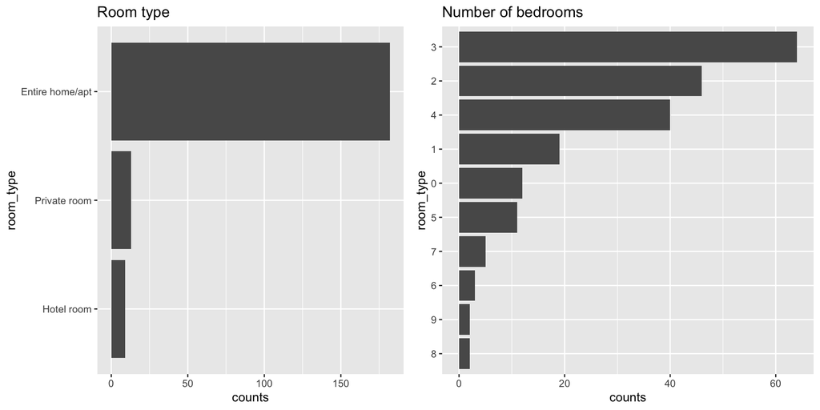

Moreover, we find the room type of most of these listings with high price is entire home/apt and the number of bedrooms are about 2-4. This result may explain the high price of these listings. Booking a big apratment in Midtown of Manhattan is reasonable to be expensive.

Cleaning fee

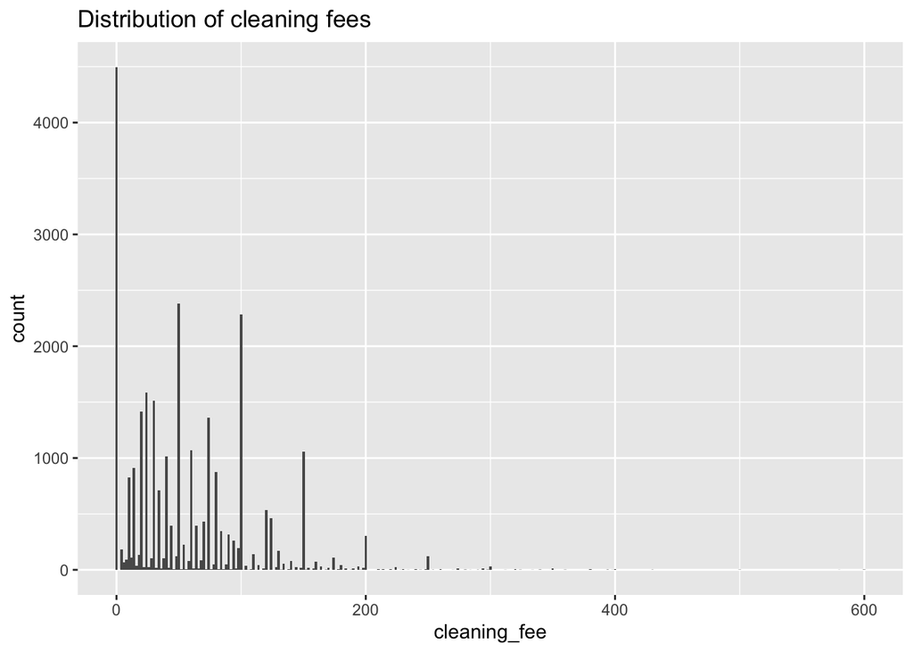

[figure not shown]

```r
ggplot(data = airbnb_cleaned, aes(x = cleaning_fee)) + geom_histogram(binwidth = 2)+
  ggtitle("Distribution of cleaning fees")
```

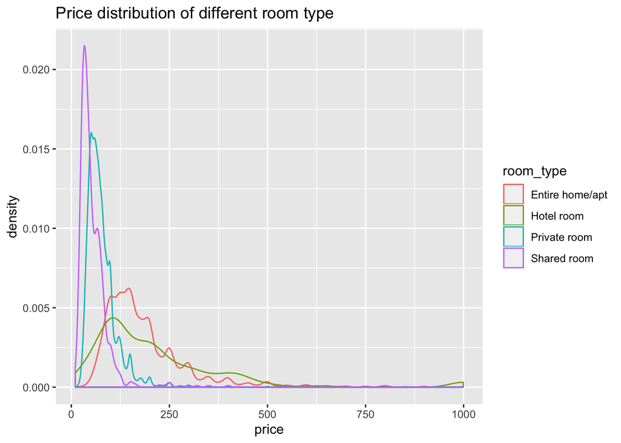

```r
#Price distribution of different room type
ggplot(airbnb_cleaned, aes(x= price, color = room_type)) + geom_density() +
  ggtitle("Price distribution of different room type")
```

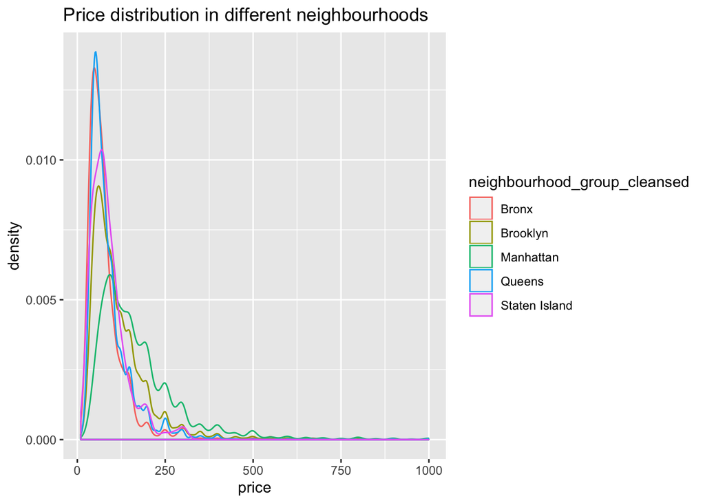

```r
#Price distribution of different neighborhood
ggplot(airbnb_cleaned, aes(x= price, color = neighbourhood_group_cleansed)) + geom_density() +
  ggtitle("Price distribution in different neighbourhoods")
```

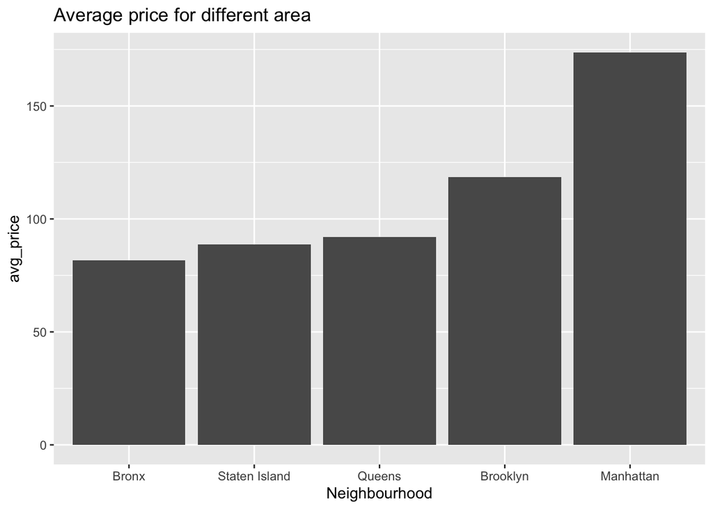

```r
#average price for different area
avg_airbnb <- airbnb_cleaned %>%
  group_by(neighbourhood_group_cleansed) %>%
  summarize(avg_price = mean(price)) %>%
  arrange(desc(avg_price))
colnames(avg_airbnb) <- c("neighbourhood","avg_price" )


ggplot(avg_airbnb) +
  geom_bar(aes(x = reorder(neighbourhood, avg_price), y = avg_price),stat="identity") +
  xlab("Neighbourhood") +
  ggtitle("Average price for different area ")
```

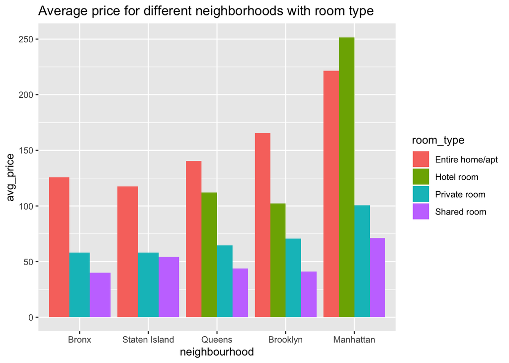

```r
avg_airbnb <- airbnb_cleaned %>%
  group_by(neighbourhood_group_cleansed, room_type) %>%
  summarize(avg_price = mean(price)) %>%
  arrange(neighbourhood_group_cleansed)


ggplot(avg_airbnb, aes(x = reorder(neighbourhood_group_cleansed, avg_price), y = avg_price, fill = room_type)) +
  geom_bar(stat="identity",position = "dodge") + ggtitle("Average price for different neighborhoods with room type")+
  xlab("neighbourhood")
```

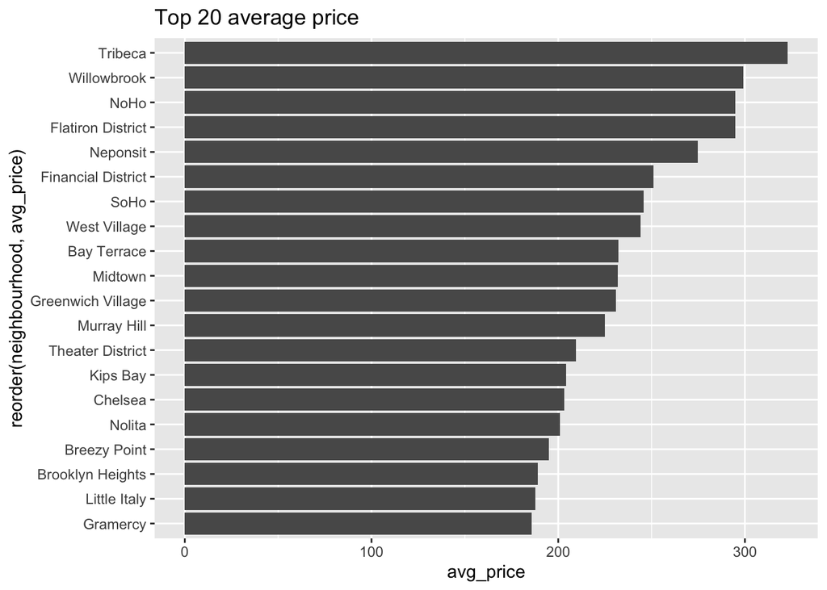

```r
#Top average price
avg_airbnb <- airbnb_cleaned %>%
  group_by(airbnb_cleaned$neighbourhood_cleansed) %>%
  summarize(avg_price = mean(price)) %>%
  arrange(desc(avg_price))
colnames(avg_airbnb) <- c("neighbourhood","avg_price" )


ggplot(avg_airbnb[1:20,]) +
  geom_bar(aes(x = reorder(neighbourhood, avg_price), y = avg_price),stat="identity") +
  coord_flip() + ggtitle("Top 20 average price ")
```

```r
#Top average price(different room type)
neigh_list <- dplyr::pull(avg_airbnb[1:10,1])

unique(airbnb_cleaned$room_type)
```

```
## [1] "Entire home/apt" "Private room"    "Shared room"     "Hotel room"
```

```r
temp <- airbnb_cleaned %>%
  group_by(neighbourhood_cleansed, room_type) %>%
  summarize(avg_price = mean(price))

temp %>% filter(room_type == "Private room") %>% arrange(desc(avg_price))
```

```
## # A tibble: 202 x 3
## # Groups:   neighbourhood_cleansed [202]
##    neighbourhood_cleansed room_type    avg_price
##    <chr>                  <chr>            <dbl>
##  1 Bay Terrace            Private room      265
##  2 Breezy Point           Private room      195
##  3 Belle Harbor           Private room      178.
##  4 Theater District       Private room      175.
##  5 Midtown                Private room      171.
##  6 Tribeca                Private room      151.
##  7 NoHo                   Private room      139.
##  8 West Village           Private room      138.
##  9 Murray Hill            Private room      136
## 10 SoHo                   Private room      132.
## # … with 192 more rows
```